# data exploration PE462

Emna Zeghal

2022-06-27

## Pre-processing

First, I started by creating a R project and initializing a renv lock. After downloading the several needed packages (from CRAN or bioconductor). Those need to be loaded.

```r
library(phyloseq)
library(grid)
library(tidyverse)
library(vegan)
library(rmarkdown)
library(knitr)
library(DESeq2)
library(microbiome)
library(ggpubr)
library(FactoMineR)
library(factoextra)
library(usedist)
library(heatmaply)
library(Hmisc)
library(kableExtra)
library(RColorBrewer)
library(vegan)
library(pals)
```

```r
#For random iterations
set.seed(42)
```

### Importing data:

Raw data is imported in the right class to merge as a phyloseq object.

```r
tax <- as.matrix(read.delim("./original/representative_seq_set_tax_assignments.txt", row.names = 1, na.strings = "NA"))
tax <- tax_table(tax)
otu <- as.matrix(read.delim("./original/asv_table.txt", row.names = 1))
otu <- otu_table(otu, taxa_are_rows = T)
map <- sample_data(read.delim("./original/mapPE462.txt", row.names = 1, na.strings = c("NA", "")))
physeq_object <-  merge_phyloseq(otu, tax, map)
```

```r
physeq_object
## phyloseq-class experiment-level object
## otu_table()   OTU Table:         [ 9132 taxa and 246 samples ]
## sample_data() Sample Data:       [ 246 samples by 8 sample variables ]
## tax_table()   Taxonomy Table:    [ 9132 taxa by 7 taxonomic ranks ]
```

```r
##############basic information##############
summarize_phyloseq(physeq_object)
## Compositional = NO2
## 1] Min. number of reads = 1582] Max. number of reads = 1745883] Total number of reads = 109260864] Average number of reads = 44414.98373983745] Median number of reads = 356867] Sparsity = 0.9412149361309646] Any OTU sum to 1 or less? YES8] Number of singletons = 1119] Percent of OTUs that are singletons
##         (i.e. exactly one read detected across all samples)1.2155059132720110] Number of sample variables are: 8replicateDescriptiontreatmentmaterialpolymertimepoint.days.stationdetail2
## [[1]]
## [1] "1] Min. number of reads = 158"
##
## [[2]]
## [1] "2] Max. number of reads = 174588"
##
## [[3]]
## [1] "3] Total number of reads = 10926086"
##
## [[4]]
## [1] "4] Average number of reads = 44414.9837398374"
##
## [[5]]
## [1] "5] Median number of reads = 35686"
##
## [[6]]
## [1] "7] Sparsity = 0.941214936130964"
##
## [[7]]
## [1] "6] Any OTU sum to 1 or less? YES"
##
## [[8]]
## [1] "8] Number of singletons = 111"
##
## [[9]]
## [1] "9] Percent of OTUs that are singletons \n        (i.e. exactly one read detected across all samples)1.21550591327201"
##
## [[10]]
## [1] "10] Number of sample variables are: 8"
##
## [[11]]
## [1] "replicate"       "Description"     "treatment"       "material"
## [5] "polymer"         "timepoint.days." "station"         "detail"
ntaxa(physeq_object)
## [1] 9132
nsamples(physeq_object)
## [1] 246
head(sample_names(physeq_object))
## [1] "NIOZ186.001.250" "NIOZ186.003.252" "NIOZ186.005.254" "NIOZ186.009.002"
## [5] "NIOZ186.011.004" "NIOZ186.013.006"
head(taxa_names(physeq_object))
## [1] "asv.1" "asv.2" "asv.3" "asv.4" "asv.5" "asv.6"
rank_names(physeq_object)
## [1] "Kingdom" "Phylum"  "Class"   "Order"   "Family"  "Genus"   "Species"
head(sample_sums(physeq_object))
## NIOZ186.001.250 NIOZ186.003.252 NIOZ186.005.254 NIOZ186.009.002 NIOZ186.011.004
##           82496           55276           97604           62242           68355
## NIOZ186.013.006
##           52841
head(taxa_sums(physeq_object))
##  asv.1  asv.2  asv.3  asv.4  asv.5  asv.6
## 438349 408305 335876 285068 280422 246351
min(sample_sums(physeq_object))
## [1] 158
#eliminate singletons
physeq_object <- filter_taxa(physeq_object, function(x) sum(x) > 1, TRUE)
```

```r
##########getting rid of wonky taxonomy assignments ###########
get_taxa_unique(physeq_object, "Kingdom") # unassigned in kingdoms
## [1] "Bacteria"  "Eukaryota" "Archaea"   NA
 #let's eliminate those otus
physeq_object <- subset_taxa(physeq_object, !is.na(Kingdom) & !Kingdom%in% c("", "Unassigned"))
get_taxa_unique(physeq_object, "Kingdom")
## [1] "Bacteria"  "Eukaryota" "Archaea"
# let's check the Phyla, there's "NA"
any(is.na(get_taxa_unique(physeq_object, "Phylum")))
## [1] TRUE
physeq_object <- subset_taxa(physeq_object, !is.na(Phylum) & !Phylum%in% c("NA"," NA" ))
#let's verify
any(is.na(get_taxa_unique(physeq_object, "Phylum")))
## [1] FALSE
#number of Phyla
length(get_taxa_unique(physeq_object,"Phylum"))
## [1] 45
#getting rid of Chloroplast & Mitochondria
any((get_taxa_unique(physeq_object, "Order") == "Chloroplast"))
## [1] TRUE
any((get_taxa_unique(physeq_object, "Family") == "Mitochondria"))
## [1] TRUE
physeq_object <- subset_taxa(physeq_object, !Order%in% c("Chloroplast"))
physeq_object <- subset_taxa(physeq_object, !Family%in% c("Mitochondria"))
any((get_taxa_unique(physeq_object, "Order") == "Chloroplast" & !is.na((get_taxa_unique(physeq_object, "Order")))))
## [1] FALSE
any((get_taxa_unique(physeq_object, "Family") == "Mitochondria")& !is.na(get_taxa_unique(physeq_object, "Family")))
## [1] FALSE
#no singletons
physeq_object <- prune_taxa(taxa_sums(physeq_object) > 1, physeq_object)
```

```r
#loops to redefine weird taxonomy to a single common character string "unassigned"
taxo <- as.data.frame(physeq_object@tax_table)


for (i in 1:nrow(taxo)) {
  for (y in 1:ncol(taxo)) {
    if
    (is.na(taxo[i,y]) || any(str_detect(taxo[i,y], c("uncultured","Uncultured","metagenome", "Metagenome","unknown", "Unknown","NA")))) {
      taxo[i,y] <- "unassigned" }
  }
}

taxo <- tax_table(as.matrix(taxo))
```

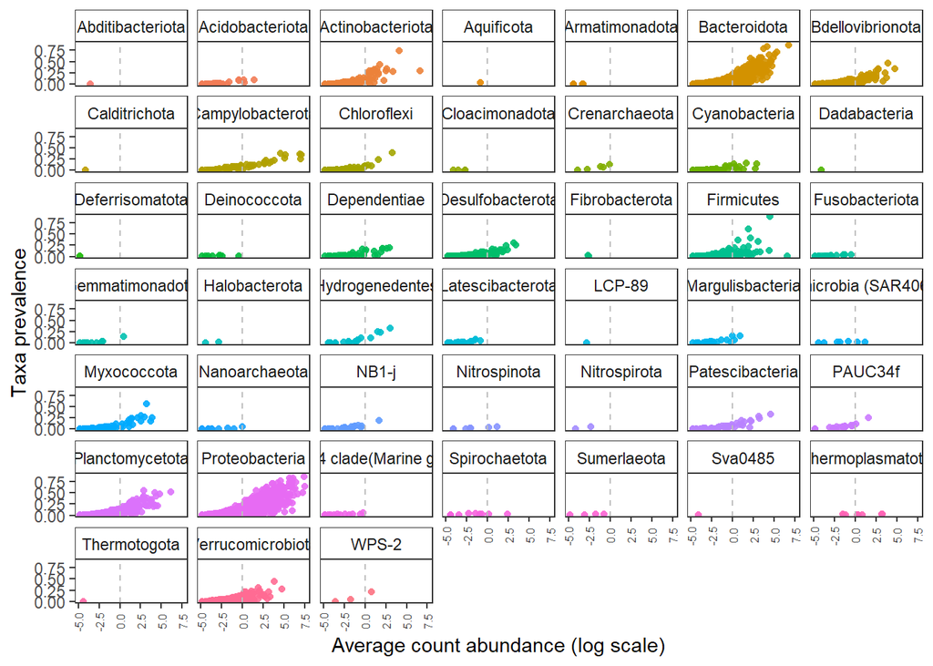

Prevalence of all detected Phyla

```r
physeq_object <- merge_phyloseq(physeq_object@otu_table, taxo, map)
```

### Alpha diversity:

Let’s calculate Alpha diversity indexes. I am using here two different packages. One is enough. I was just curious if the output would be the same.

```r
############### alpha div ###################
#microbiome package alpha div indexes
summarize_phyloseq(physeq_object)
alpha_tab <-microbiome::alpha(physeq_object, index = "all")
alpha_tab <- alpha_tab %>% cbind(data.frame(physeq_object@sam_data))
#write_csv(alpha_tab, file = "./alpha_div_indexes_microbiome_package.csv")
#phyloseq package
alpha <- phyloseq::estimate_richness(physeq_object)
#write_csv(alpha, file = "./alpha_div_phyloseq.csv")
```

Alpha diversity idexes table

|  | observed | chao1 | diversity_inverse_simpson | diversity_gini_simpson | diversity_shannon | diversity_fisher | diversity_coverage | evenness_camargo | evenness_pielou | evenness_simpson | evenness_evar | evenness_bulla | dominance_dbp | dominance_dmn | dominance_absolute | dominance_relative | dominance_simpson | dominance_core_abundance | dominance_gini | rarity_log_modulo_skewness | rarity_low_abundance | rarity_rare_abundance | replicate | Description | treatment | material | polymer | timepoint.days. | station | … |
| --- | --- | --- | --- | --- | --- | --- | --- | --- | --- | --- | --- | --- | --- | --- | --- | --- | --- | --- | --- | --- | --- | --- | --- | --- | --- | --- | --- | --- | --- | --- |
| NIOZ186.001.250 | 456 | 469.72 | 10.02 | 0.90 | 3.42 | 64.50 | 5 | 0.09 | 0.56 | 0.02 | 0.18 | 0.21 | 0.27 | 0.37 | 20756 | 0.27 | 0.10 | 0.00 | 1.00 | 2.06 | 0.09 | 0.33 | 1 | B1.1_D5 | no_UV | plastic | PE | 5 | C05 | … |
| NIOZ186.003.252 | 394 | 398.25 | 14.81 | 0.93 | 3.76 | 58.49 | 6 | 0.15 | 0.63 | 0.04 | 0.21 | 0.26 | 0.19 | 0.31 | 9503 | 0.19 | 0.07 | 0.01 | 0.99 | 2.06 | 0.11 | 0.35 | 2 | B1.2_D5 | no_UV | plastic | PE | 5 | C05 | … |
| NIOZ186.005.254 | 451 | 455.44 | 16.58 | 0.94 | 3.70 | 61.97 | 5 | 0.11 | 0.61 | 0.04 | 0.19 | 0.23 | 0.15 | 0.26 | 13250 | 0.15 | 0.06 | 0.00 | 0.99 | 2.06 | 0.11 | 0.39 | 3 | B1.3_D5 | no_UV | plastic | PE | 5 | C05 | … |
| NIOZ186.009.002 | 469 | 479.11 | 8.86 | 0.89 | 3.54 | 69.96 | 5 | 0.11 | 0.58 | 0.02 | 0.20 | 0.24 | 0.31 | 0.40 | 17521 | 0.31 | 0.11 | 0.00 | 0.99 | 2.06 | 0.11 | 0.35 | 2 | B1.5_D5 | UV | plastic | PE | 5 | C05 | … |
| NIOZ186.011.004 | 384 | 384.55 | 14.95 | 0.93 | 3.75 | 54.14 | 6 | 0.15 | 0.63 | 0.04 | 0.24 | 0.27 | 0.17 | 0.31 | 11137 | 0.17 | 0.07 | 0.00 | 0.99 | 2.06 | 0.12 | 0.33 | 3 | B1.6_D5 | UV | plastic | PE | 5 | C05 | … |
| NIOZ186.013.006 | 303 | 311.55 | 4.34 | 0.77 | 2.76 | 42.78 | 2 | 0.11 | 0.48 | 0.01 | 0.18 | 0.21 | 0.47 | 0.54 | 23793 | 0.47 | 0.23 | 0.00 | 1.00 | 2.06 | 0.07 | 0.28 | 1 | B1.C_D5 | no | wood | PE_wood | 5 | C05 | … |
| NIOZ186.015.008 | 424 | 432.88 | 7.03 | 0.86 | 3.29 | 59.27 | 4 | 0.10 | 0.54 | 0.02 | 0.18 | 0.22 | 0.36 | 0.42 | 27007 | 0.36 | 0.14 | 0.01 | 1.00 | 2.06 | 0.10 | 0.32 | 1 | B2.1_D5 | no_UV | plastic | PS | 5 | C05 | … |
| NIOZ186.017.010 | 373 | 395.94 | 4.84 | 0.79 | 2.94 | 53.67 | 3 | 0.10 | 0.50 | 0.01 | 0.19 | 0.21 | 0.44 | 0.50 | 24679 | 0.44 | 0.21 | 0.01 | 1.00 | 2.06 | 0.10 | 0.31 | 2 | B2.2_D5 | no_UV | plastic | PS | 5 | C05 | … |
| NIOZ186.019.012 | 399 | 419.03 | 6.53 | 0.85 | 3.20 | 56.04 | 4 | 0.10 | 0.53 | 0.02 | 0.17 | 0.21 | 0.37 | 0.42 | 25833 | 0.37 | 0.15 | 0.00 | 1.00 | 2.06 | 0.10 | 0.31 | 3 | B2.3_D5 | no_UV | plastic | PS | 5 | C05 | … |
| NIOZ186.021.014 | 393 | 400.07 | 5.94 | 0.83 | 3.01 | 55.07 | 3 | 0.10 | 0.50 | 0.02 | 0.19 | 0.20 | 0.38 | 0.48 | 26389 | 0.38 | 0.17 | 0.00 | 1.00 | 2.06 | 0.10 | 0.30 | 1 | B2.4_D5 | UV | plastic | PS | 5 | C05 | … |
| NIOZ186.023.016 | 435 | 448.98 | 12.20 | 0.92 | 3.39 | 59.92 | 5 | 0.09 | 0.56 | 0.03 | 0.17 | 0.20 | 0.21 | 0.33 | 17877 | 0.21 | 0.08 | 0.00 | 1.00 | 2.06 | 0.10 | 0.37 | 2 | B2.5_D5 | UV | plastic | PS | 5 | C05 | … |
| NIOZ186.025.018 | 388 | 394.33 | 9.01 | 0.89 | 3.28 | 53.43 | 4 | 0.10 | 0.55 | 0.02 | 0.19 | 0.21 | 0.28 | 0.41 | 21532 | 0.28 | 0.11 | 0.00 | 1.00 | 2.06 | 0.10 | 0.34 | 3 | B2.6_D5 | UV | plastic | PS | 5 | C05 | … |
| NIOZ186.027.020 | 328 | 346.50 | 4.09 | 0.76 | 2.77 | 47.49 | 2 | 0.12 | 0.48 | 0.01 | 0.19 | 0.21 | 0.48 | 0.54 | 22902 | 0.48 | 0.24 | 0.00 | 1.00 | 2.06 | 0.09 | 0.34 | 1 | B2.C_D5 | no | wood | PS_wood | 5 | C05 | … |
| NIOZ186.029.022 | 443 | 446.08 | 22.39 | 0.96 | 4.03 | 63.41 | 10 | 0.14 | 0.66 | 0.05 | 0.18 | 0.26 | 0.13 | 0.25 | 8685 | 0.13 | 0.04 | 0.01 | 0.99 | 2.06 | 0.11 | 0.46 | 1 | B3.1_D5 | no_UV | plastic | PET | 5 | C05 | … |
| NIOZ186.031.024 | 550 | 554.75 | 41.19 | 0.98 | 4.47 | 81.75 | 15 | 0.16 | 0.71 | 0.07 | 0.20 | 0.28 | 0.07 | 0.13 | 5030 | 0.07 | 0.02 | 0.01 | 0.99 | 2.06 | 0.15 | 0.54 | 2 | B3.2_D5 | no_UV | plastic | PET | 5 | C05 | … |
| NIOZ186.033.026 | 509 | 519.78 | 27.78 | 0.96 | 4.21 | 74.86 | 11 | 0.14 | 0.68 | 0.05 | 0.18 | 0.27 | 0.12 | 0.20 | 8208 | 0.12 | 0.04 | 0.01 | 0.99 | 2.06 | 0.12 | 0.48 | 3 | B3.3_D5 | no_UV | plastic | PET | 5 | C05 | … |
| NIOZ186.035.028 | 408 | 412.12 | 24.11 | 0.96 | 3.98 | 59.54 | 9 | 0.14 | 0.66 | 0.06 | 0.19 | 0.25 | 0.12 | 0.21 | 6649 | 0.12 | 0.04 | 0.02 | 0.99 | 2.06 | 0.11 | 0.49 | 1 | B3.4_D5 | UV | plastic | PET | 5 | C05 | … |
| NIOZ186.037.030 | 490 | 496.13 | 30.91 | 0.97 | 4.18 | 71.61 | 11 | 0.13 | 0.68 | 0.06 | 0.18 | 0.25 | 0.10 | 0.17 | 6411 | 0.10 | 0.03 | 0.02 | 0.99 | 2.06 | 0.12 | 0.54 | 2 | B3.5_D5 | UV | plastic | PET | 5 | C05 | … |
| NIOZ186.039.032 | 421 | 423.46 | 23.27 | 0.96 | 4.03 | 59.94 | 10 | 0.15 | 0.67 | 0.06 | 0.18 | 0.27 | 0.12 | 0.23 | 7929 | 0.12 | 0.04 | 0.02 | 0.99 | 2.06 | 0.11 | 0.50 | 3 | B3.6_D5 | UV | plastic | PET | 5 | C05 | … |
| NIOZ186.041.034 | 377 | 395.57 | 16.39 | 0.94 | 3.62 | 54.22 | 6 | 0.11 | 0.61 | 0.04 | 0.17 | 0.22 | 0.15 | 0.27 | 8636 | 0.15 | 0.06 | 0.00 | 1.00 | 2.06 | 0.10 | 0.55 | 1 | B3.C_D5 | no | wood | PET_wood | 5 | C05 | … |
| NIOZ186.043.036 | 535 | 539.78 | 16.74 | 0.94 | 3.97 | 74.60 | 9 | 0.12 | 0.63 | 0.03 | 0.19 | 0.26 | 0.18 | 0.31 | 17269 | 0.18 | 0.06 | 0.05 | 0.99 | 2.06 | 0.13 | 0.43 | 1 | B4.1_D5 | no_UV | plastic | Nylon | 5 | C05 | … |
| NIOZ186.045.038 | 449 | 451.84 | 14.60 | 0.93 | 3.85 | 66.02 | 8 | 0.13 | 0.63 | 0.03 | 0.20 | 0.26 | 0.19 | 0.34 | 11500 | 0.19 | 0.07 | 0.04 | 0.99 | 2.06 | 0.12 | 0.43 | 2 | B4.2_D5 | no_UV | plastic | Nylon | 5 | C05 | … |
| NIOZ186.047.040 | 520 | 524.38 | 41.55 | 0.98 | 4.42 | 74.88 | 15 | 0.15 | 0.71 | 0.08 | 0.19 | 0.27 | 0.07 | 0.13 | 5538 | 0.07 | 0.02 | 0.06 | 0.99 | 2.06 | 0.13 | 0.49 | 3 | B4.3_D5 | no_UV | plastic | Nylon | 5 | C05 | … |
| NIOZ186.049.042 | 414 | 429.28 | 17.08 | 0.94 | 3.80 | 60.60 | 8 | 0.12 | 0.63 | 0.04 | 0.18 | 0.24 | 0.18 | 0.29 | 9998 | 0.18 | 0.06 | 0.08 | 0.99 | 2.06 | 0.11 | 0.37 | 1 | B4.4_D5 | UV | plastic | Nylon | 5 | C05 | … |
| NIOZ186.051.044 | 443 | 450.74 | 17.48 | 0.94 | 3.73 | 60.60 | 7 | 0.11 | 0.61 | 0.04 | 0.17 | 0.23 | 0.14 | 0.26 | 12252 | 0.14 | 0.06 | 0.07 | 0.99 | 2.06 | 0.11 | 0.40 | 2 | B4.5_D5 | UV | plastic | Nylon | 5 | C05 | … |
| NIOZ186.053.046 | 372 | 377.00 | 19.93 | 0.95 | 3.91 | 54.78 | 9 | 0.15 | 0.66 | 0.05 | 0.20 | 0.27 | 0.16 | 0.25 | 7920 | 0.16 | 0.05 | 0.07 | 0.99 | 2.06 | 0.10 | 0.44 | 3 | B4.6_D5 | UV | plastic | Nylon | 5 | C05 | … |
| NIOZ186.055.048 | 456 | 475.13 | 23.79 | 0.96 | 4.03 | 63.94 | 10 | 0.14 | 0.66 | 0.05 | 0.16 | 0.26 | 0.14 | 0.22 | 10853 | 0.14 | 0.04 | 0.02 | 0.99 | 2.06 | 0.12 | 0.58 | 1 | B4.C_D5 | no | wood | Nylon_wood | 5 | C05 | … |
| NIOZ186.057.050 | 609 | 642.02 | 15.96 | 0.94 | 3.76 | 90.37 | 6 | 0.11 | 0.59 | 0.03 | 0.19 | 0.21 | 0.16 | 0.28 | 11974 | 0.16 | 0.06 | 0.00 | 0.99 | 2.06 | 0.13 | 0.66 | 1 | B5.1_D5 | no_UV | plastic | PE | 5 | C13 | … |
| NIOZ186.059.052 | 733 | 761.75 | 10.41 | 0.90 | 3.56 | 110.42 | 4 | 0.10 | 0.54 | 0.01 | 0.21 | 0.20 | 0.21 | 0.41 | 17812 | 0.21 | 0.10 | 0.00 | 0.99 | 2.06 | 0.13 | 0.60 | 2 | B5.2_D5 | no_UV | plastic | PE | 5 | C13 | … |
| NIOZ186.061.054 | 524 | 542.83 | 7.00 | 0.86 | 3.14 | 73.75 | 3 | 0.08 | 0.50 | 0.01 | 0.18 | 0.18 | 0.34 | 0.47 | 30229 | 0.34 | 0.14 | 0.00 | 1.00 | 2.06 | 0.11 | 0.53 | 3 | B5.3_D5 | no_UV | plastic | PE | 5 | C13 | … |

[output cut: 216 more lines]

### A focus on the wooden stirrers controls:

Let’s try to determine if the Alpha diversity between the different bottles of incubation for the wooden stirrers are really different (for each timepoint and station of course). Combining those to “create” replicates could be interesting.

#### Alpha diversity graphic glimpse:

```r
m <- alpha_tab %>% filter(material =="wood")
```

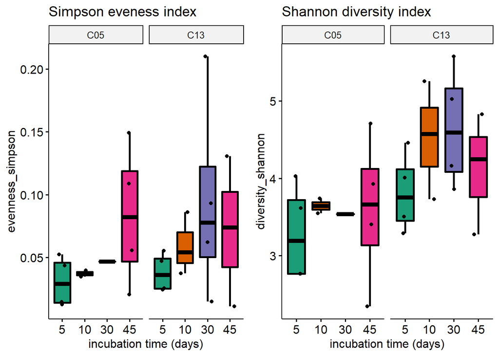

```r
p <- ggboxplot(m, x = "timepoint.days.", y = "evenness_simpson",
               fill = "timepoint.days.", palette ="Dark2",
              add = "jitter", size = 1) +facet_wrap(~station)
p <- ggpar(p,legend = "none",xlab ="incubation time (days)", title = "Simpson eveness index")

p2 <- ggboxplot(m, x = "timepoint.days.", y = "diversity_shannon",
               fill = "timepoint.days.", palette ="Dark2",
              add = "jitter", size = 1) +facet_wrap(~station)
p2 <- ggpar(p2,legend = "none",xlab ="incubation time (days)", title = "Shannon diversity index")
ggarrange (p, p2, ncol=2)
```

#### Kruskal wallis tests for each station/timepoint combination:

##### coastal station / day 5:

```r
kruskal.test(diversity_shannon ~ polymer, data = (m %>% filter (station =="C05") %>% filter(timepoint.days. == "5")))
##
##  Kruskal-Wallis rank sum test
##
## data:  diversity_shannon by polymer
## Kruskal-Wallis chi-squared = 3, df = 3, p-value = 0.3916
kruskal.test(evenness_simpson ~ polymer, data = (m %>% filter (station =="C05") %>% filter(timepoint.days. == "5")))
##
##  Kruskal-Wallis rank sum test
##
## data:  evenness_simpson by polymer
## Kruskal-Wallis chi-squared = 3, df = 3, p-value = 0.3916
```

##### coastal station / day 10:

```r
kruskal.test(diversity_shannon ~ polymer, data = (m %>% filter (station =="C05") %>% filter(timepoint.days. == "10")))
##
##  Kruskal-Wallis rank sum test
##
## data:  diversity_shannon by polymer
## Kruskal-Wallis chi-squared = 1, df = 1, p-value = 0.3173
kruskal.test(evenness_simpson ~ polymer, data = (m %>% filter (station =="C05") %>% filter(timepoint.days. == "10")))
##
##  Kruskal-Wallis rank sum test
##
## data:  evenness_simpson by polymer
## Kruskal-Wallis chi-squared = 1, df = 1, p-value = 0.3173
```

##### coastal station / day 45:

```r
kruskal.test(diversity_shannon ~ polymer, data = (m %>% filter (station =="C05") %>% filter(timepoint.days. == "45")))
##
##  Kruskal-Wallis rank sum test
##
## data:  diversity_shannon by polymer
## Kruskal-Wallis chi-squared = 3, df = 3, p-value = 0.3916
kruskal.test(evenness_simpson ~ polymer, data = (m %>% filter (station =="C05") %>% filter(timepoint.days. == "45")))
##
##  Kruskal-Wallis rank sum test
##
## data:  evenness_simpson by polymer
## Kruskal-Wallis chi-squared = 3, df = 3, p-value = 0.3916
```

None of the tests above showed significant differences (p<0.05). Combining wooden stirrers for each timepoint might be considered.

##### offshore station / day 5:

```r
kruskal.test(diversity_shannon ~ polymer, data = (m %>% filter (station =="C13") %>% filter(timepoint.days. == "5")))
##
##  Kruskal-Wallis rank sum test
##
## data:  diversity_shannon by polymer
## Kruskal-Wallis chi-squared = 3, df = 3, p-value = 0.3916
kruskal.test(evenness_simpson ~ polymer, data = (m %>% filter (station =="C13") %>% filter(timepoint.days. == "5")))
##
##  Kruskal-Wallis rank sum test
##
## data:  evenness_simpson by polymer
## Kruskal-Wallis chi-squared = 3, df = 3, p-value = 0.3916
```

##### offshore station / day 10:

```r
kruskal.test(diversity_shannon ~ polymer, data = (m %>% filter (station =="C13") %>% filter(timepoint.days. == "10")))
##
##  Kruskal-Wallis rank sum test
##
## data:  diversity_shannon by polymer
## Kruskal-Wallis chi-squared = 2, df = 2, p-value = 0.3679
kruskal.test(evenness_simpson ~ polymer, data = (m %>% filter (station =="C13") %>% filter(timepoint.days. == "10")))
##
##  Kruskal-Wallis rank sum test
##
## data:  evenness_simpson by polymer
## Kruskal-Wallis chi-squared = 2, df = 2, p-value = 0.3679
```

##### offshore station / day 30:

```r
kruskal.test(diversity_shannon ~ polymer, data = (m %>% filter (station =="C13") %>% filter(timepoint.days. == "30")))
##
##  Kruskal-Wallis rank sum test
##
## data:  diversity_shannon by polymer
## Kruskal-Wallis chi-squared = 3, df = 3, p-value = 0.3916
kruskal.test(evenness_simpson ~ polymer, data = (m %>% filter (station =="C13") %>% filter(timepoint.days. == "30")))
##
##  Kruskal-Wallis rank sum test
##
## data:  evenness_simpson by polymer
## Kruskal-Wallis chi-squared = 3, df = 3, p-value = 0.3916
```

##### offshore station / day 45:

```r
kruskal.test(diversity_shannon ~ polymer, data = (m %>% filter (station =="C13") %>% filter(timepoint.days. == "45")))
##
##  Kruskal-Wallis rank sum test
##
## data:  diversity_shannon by polymer
## Kruskal-Wallis chi-squared = 2, df = 2, p-value = 0.3679
kruskal.test(evenness_simpson ~ polymer, data = (m %>% filter (station =="C13") %>% filter(timepoint.days. == "45")))
##
##  Kruskal-Wallis rank sum test
##
## data:  evenness_simpson by polymer
## Kruskal-Wallis chi-squared = 2, df = 2, p-value = 0.3679
```

None of the tests above showed significant differences (p<0.05). Combining wooden stirrers for each timepoint might be considered.  
According to the results above. wooden stirrers might be pooled for each station/timepoint combination.

## Data transformation

Now, I am transforming my data in a “tidy” way to make use of the function implemented in the tidyverse. I am mainly referring to grouping functions that will allow quick calculations of mean abundances and standard deviation for replicates without writing loops.  
For that I am going to use the tidy_psmelt function (written by mikemc github user). tidy_psmelt source code is saved in the project repository.

### Tidying the data:

```r
source("./tidy_psmelt.R")
tidy_physeq_asv <- tidy_psmelt(physeq_object)
#append genus to the species name
tidy_physeq_asv$Species <- if_else(!tidy_physeq_asv$Species=="unassigned", str_c(tidy_physeq_asv$Genus," ",tidy_physeq_asv$Species), tidy_physeq_asv$Species)
#correct colum detail for wood to be able to merge the "replicates"
tidy_physeq_asv$detail <- if_else(tidy_physeq_asv$material=="wood", str_c(tidy_physeq_asv$material,"_",tidy_physeq_asv$station,"_",tidy_physeq_asv$timepoint.days.), tidy_physeq_asv$detail)
#write_csv(tidy_physeq_asv, "./new/tidyPE462")
```

### Abundances calculations:

I am going to calculate the mean abundances of each agglomerated taxonomic rank per sample and per replicates.

```r
tidy_physeq_asv <- read.csv("./new/tidyPE462.csv")

t3 <- tidy_physeq_asv  %>% group_by(Sample) %>% mutate(Sample_rel_abund = Abundance / sum(Abundance)) %>% #relative abundance of each asv per sample
  ungroup() %>%
  group_by(detail) %>% mutate( rep_rel_abund = Sample_rel_abund / sum(Sample_rel_abund)) %>% #relative abundance of each asv per number of samples in replicates
  ungroup() %>%
  #Kingdom_section
  group_by(Sample, Kingdom) %>%
  mutate(Kingdom_rel_abund_Sample = sum(Sample_rel_abund)) %>%  #Kingdom relative abundance per sample
  ungroup() %>%
  group_by(detail, Kingdom) %>%
  mutate(Kingdom_st_dev_abund_samples = sd(Kingdom_rel_abund_Sample)) %>% # standard dev of Kingdom relative abundances between replicates of column detail
  mutate(Kingdom_rep_rel_abund = sum(rep_rel_abund)) %>% #Kingdom relative abundance per samples of desc
  ungroup() %>%
  #Phylum_section
  group_by(Sample, Phylum) %>%
  mutate(Phylum_rel_abund_Sample = sum(Sample_rel_abund)) %>%
  ungroup() %>%
  group_by(detail, Phylum) %>%
  mutate(st_dev_Phylum_abund = sd(Phylum_rel_abund_Sample)) %>%
  mutate(Phyla_rep_rel_abund = sum(rep_rel_abund)) %>%
  ungroup() %>%
  #Class_section
  group_by(Sample, Class) %>%
  mutate(Class_rel_abund_Sample = sum(Sample_rel_abund)) %>%
  ungroup() %>%
  group_by(detail, Class) %>%
  mutate(st_dev_Class_abund = sd(Class_rel_abund_Sample)) %>%
  mutate(Class_rep_rel_abund = sum(rep_rel_abund)) %>%
  ungroup() %>%
  #Order_section
  group_by(Sample, Order) %>%
  mutate(Order_rel_abund_Sample = sum(Sample_rel_abund)) %>%
  ungroup() %>%
  group_by(detail, Order) %>%
  mutate(st_dev_Order_abund = sd(Order_rel_abund_Sample)) %>%
  mutate(Order_rep_rel_abund = sum(rep_rel_abund)) %>%
  ungroup() %>%
  #Family_section
  group_by(Sample, Family) %>%
  mutate(Family_rel_abund_Sample = sum(Sample_rel_abund)) %>%
  ungroup() %>%
  group_by(detail, Family) %>%
  mutate(st_dev_Family_abund = sd(Family_rel_abund_Sample)) %>%
  mutate(Family_rep_rel_abund = sum(rep_rel_abund)) %>%
  ungroup() %>%
  #Genus_section
  group_by(Sample, Genus) %>%
  mutate(Genus_rel_abund_Sample = sum(Sample_rel_abund)) %>%
  ungroup() %>%
  group_by(detail, Genus) %>%
  mutate(st_dev_Genus_abund = sd(Genus_rel_abund_Sample)) %>%
  mutate(Genus_rep_rel_abund = sum(rep_rel_abund)) %>%
  ungroup() %>%
  #Species_section
  group_by(Sample, Species) %>%
  mutate(Species_rel_abund_Sample = sum(Sample_rel_abund)) %>%
  ungroup() %>%
  group_by(detail, Species) %>%
  mutate(st_dev_Species_abund = sd(Species_rel_abund_Sample)) %>%
  mutate(Species_rep_rel_abund = sum(rep_rel_abund)) %>%
  ungroup()

polymer_station <-  str_c(t3$polymer, "_", t3$station)
polymer_photo <- str_c(t3$polymer, "_", t3$treatment)
pol_photo_station <- str_c(t3$polymer_photo, "_", t3$station)
t3 <- t3 %>%
  add_column(polymer_station, .before ="Kingdom") %>%
  add_column(polymer_photo, .before ="Kingdom") %>%
  add_column(pol_photo_station, .before ="Kingdom")

t3$polymer_station <- if_else(t3$material=="wood", str_c(t3$material,"_",t3$station), t3$polymer_station)
t3$polymer_photo <- if_else(t3$material=="wood", str_c(t3$material,"_",t3$treatment), t3$polymer_photo)
t3$pol_photo_station <- if_else(t3$material=="wood", str_c(t3$material,"_",t3$treatment,"_",t3$station), t3$pol_photo_station)


#write_csv(t3, "./new/tidyPE462_abundances_calc_w.csv")
```

First 10 rows of the tidy transformed datset

| OTU | Sample | Abundance | replicate | Description | treatment | material | polymer | timepoint.days. | station | detail | polymer_station | polymer_photo | pol_photo_station | Kingdom | Phylum | Class | Order | Family | Genus | Species | Sample_rel_abund | rep_rel_abund | Kingdom_rel_abund_Sample | Kingdom_st_dev_abund_samples | Kingdom_rep_rel_abund | Phylum_rel_abund_Sample | st_dev_Phylum_abund | Phyla_rep_rel_abund | Class_rel_abund_Sample | … |
| --- | --- | --- | --- | --- | --- | --- | --- | --- | --- | --- | --- | --- | --- | --- | --- | --- | --- | --- | --- | --- | --- | --- | --- | --- | --- | --- | --- | --- | --- | --- |
| asv.10 | NIOZ322.241.226 | 96074 | 2 | Mock_Zdna-D6311_2 | no | no | mock_DNA | mock_DNA | mock_DNA | mock_DNA | mock_DNA_mock_DNA | mock_DNA_no | _mock_DNA | Bacteria | Firmicutes | Bacilli | Lactobacillales | Listeriaceae | Listeria | Listeria innocua/ivanovii/marthii/monocytogenes/phage/seeligeri/welshimeri | 0.97 | 0.48 | 1 | 0 | 1 | 0.98 | 0.00 | 0.98 | 0.98 | … |
| asv.10 | NIOZ322.239.224 | 84973 | 1 | Mock_Zdna-D6311_1 | no | no | mock_DNA | mock_DNA | mock_DNA | mock_DNA | mock_DNA_mock_DNA | mock_DNA_no | _mock_DNA | Bacteria | Firmicutes | Bacilli | Lactobacillales | Listeriaceae | Listeria | Listeria innocua/ivanovii/marthii/monocytogenes/phage/seeligeri/welshimeri | 0.97 | 0.48 | 1 | 0 | 1 | 0.98 | 0.00 | 0.98 | 0.98 | … |
| asv.3 | NIOZ186.119.112 | 35632 | 1 | B1.4_D10 | UV | plastic | PE | 10 | C05 | PE_UV_C05_10 | PE_C05 | PE_UV | _C05 | Bacteria | Proteobacteria | Gammaproteobacteria | Enterobacterales | Alteromonadaceae | Alteromonas | Alteromonas australica | 0.25 | 0.08 | 1 | 0 | 1 | 0.79 | 0.02 | 0.81 | 0.52 | … |
| asv.6 | NIOZ186.061.054 | 30229 | 3 | B5.3_D5 | no_UV | plastic | PE | 5 | C13 | PE_no_UV_C13_5 | PE_C13 | PE_no_UV | _C13 | Bacteria | Campylobacterota | Campylobacteria | Campylobacterales | Arcobacteraceae | Pseudarcobacter | unassigned | 0.34 | 0.11 | 1 | 0 | 1 | 0.63 | 0.03 | 0.58 | 0.63 | … |
| asv.1 | NIOZ186.015.008 | 27007 | 1 | B2.1_D5 | no_UV | plastic | PS | 5 | C05 | PS_no_UV_C05_5 | PS_C05 | PS_no_UV | _C05 | Bacteria | Proteobacteria | Gammaproteobacteria | Enterobacterales | Pseudoalteromonadaceae | Pseudoalteromonas | Pseudoalteromonas carrageenovora/chazhmella/distincta/elyakovii/espejiana/haloplanktis/issachenkonii/paragorgicola/prydzensis/tetraodonis/undina | 0.36 | 0.12 | 1 | 0 | 1 | 0.90 | 0.01 | 0.88 | 0.76 | … |
| asv.1 | NIOZ186.021.014 | 26389 | 1 | B2.4_D5 | UV | plastic | PS | 5 | C05 | PS_UV_C05_5 | PS_C05 | PS_UV | _C05 | Bacteria | Proteobacteria | Gammaproteobacteria | Enterobacterales | Pseudoalteromonadaceae | Pseudoalteromonas | Pseudoalteromonas carrageenovora/chazhmella/distincta/elyakovii/espejiana/haloplanktis/issachenkonii/paragorgicola/prydzensis/tetraodonis/undina | 0.38 | 0.13 | 1 | 0 | 1 | 0.95 | 0.03 | 0.93 | 0.78 | … |
| asv.1 | NIOZ186.019.012 | 25833 | 3 | B2.3_D5 | no_UV | plastic | PS | 5 | C05 | PS_no_UV_C05_5 | PS_C05 | PS_no_UV | _C05 | Bacteria | Proteobacteria | Gammaproteobacteria | Enterobacterales | Pseudoalteromonadaceae | Pseudoalteromonas | Pseudoalteromonas carrageenovora/chazhmella/distincta/elyakovii/espejiana/haloplanktis/issachenkonii/paragorgicola/prydzensis/tetraodonis/undina | 0.37 | 0.12 | 1 | 0 | 1 | 0.88 | 0.01 | 0.88 | 0.72 | … |
| asv.3 | NIOZ186.121.114 | 25050 | 2 | B1.5_D10 | UV | plastic | PE | 10 | C05 | PE_UV_C05_10 | PE_C05 | PE_UV | _C05 | Bacteria | Proteobacteria | Gammaproteobacteria | Enterobacterales | Alteromonadaceae | Alteromonas | Alteromonas australica | 0.16 | 0.05 | 1 | 0 | 1 | 0.81 | 0.02 | 0.81 | 0.54 | … |
| asv.4 | NIOZ186.099.092 | 24949 | 1 | B8.1_D5 | no_UV | plastic | Nylon | 5 | C13 | Nylon_no_UV_C13_5 | Nylon_C13 | Nylon_no_UV | _C13 | Bacteria | Campylobacterota | Campylobacteria | Campylobacterales | Arcobacteraceae | Pseudarcobacter | unassigned | 0.25 | 0.08 | 1 | 0 | 1 | 0.55 | 0.10 | 0.52 | 0.55 | … |
| asv.1 | NIOZ186.017.010 | 24679 | 2 | B2.2_D5 | no_UV | plastic | PS | 5 | C05 | PS_no_UV_C05_5 | PS_C05 | PS_no_UV | _C05 | Bacteria | Proteobacteria | Gammaproteobacteria | Enterobacterales | Pseudoalteromonadaceae | Pseudoalteromonas | Pseudoalteromonas carrageenovora/chazhmella/distincta/elyakovii/espejiana/haloplanktis/issachenkonii/paragorgicola/prydzensis/tetraodonis/undina | 0.44 | 0.15 | 1 | 0 | 1 | 0.88 | 0.01 | 0.88 | 0.77 | … |

## Community analysis

I imported the resulting datasets after pre-processing for each polymer in the working project directory.  
A common first step is to load the libraries to be used throughout the analysis. In here the packages used are already loaded (Tidyverse, phyloseq and hmisc).

### Polyethylene:

#### 1. Importing data:

The datset is imported then split into several subsets according to different parameters (UV treatment and location)

```r
#PE_analysis==============
pe <- read_csv("./new/PE462_PE.csv")
pe <- pe %>% filter(Genus %nin% c("unassigned", "Unassigned"))
    ######subset per station#########
coast <- pe %>% filter(station %in% c("C05"))
os <- pe %>% filter(station %in% c("C13"))
    #####subset stations per treatment######
coast_uv <- coast %>% filter(treatment %in% c("UV"))
coast_nuv <- coast %>% filter(treatment %in% c("no_UV"))
coast_n <- coast %>% filter(treatment %in% c("no"))
##same for 2nd station
os_uv <- os %>% filter(treatment %in% c("UV"))
os_nuv <- os %>% filter(treatment %in% c("no_UV"))
os_n <- os %>% filter(treatment %in% c("no"))
```

#### 2. Determining top genera:

here I determined the top 5 genera for each subset of the coastal station and each timepoint.

```r
coast_uv_g5 <- coast_uv %>% select(timepoint.days.,detail, Genus, Genus_rep_rel_abund, st_dev_Genus_abund) %>%
  mutate(across(c(timepoint.days.),factor))%>% distinct() %>%
  group_by(timepoint.days.) %>% slice_max(order_by = Genus_rep_rel_abund, n = 5)
coast_nuv_g5 <- coast_nuv %>% select(timepoint.days.,detail, Genus, Genus_rep_rel_abund, st_dev_Genus_abund) %>%
  mutate(across(c(timepoint.days.),factor))%>% distinct() %>%
  group_by(timepoint.days.) %>% slice_max(order_by = Genus_rep_rel_abund, n = 5)
coast_n_g5 <- coast_n %>% select(timepoint.days.,detail, Genus, Genus_rep_rel_abund, st_dev_Genus_abund) %>%
  mutate(across(c(timepoint.days.),factor))%>% distinct() %>%
  group_by(timepoint.days.) %>% slice_max(order_by = Genus_rep_rel_abund, n = 5)
```

These are the “total” top genera:

```r
unique(c(coast_nuv_g5$Genus,coast_uv_g5$Genus, coast_n_g5$Genus) )
##  [1] "Pseudoalteromonas"  "Alteromonas"        "Colwellia"
##  [4] "Aliiglaciecola"     "Pseudophaeobacter"  "Oleibacter"
##  [7] "OM27 clade"         "Oleiphilus"         "Sulfitobacter"
## [10] "Marinobacter"       "Pelagibaca"         "Gimesia"
## [13] "Ketobacter"         "Maribacter"         "Altererythrobacter"
## [16] "Pelagicoccus"       "Marinomonas"        "Aliivibrio"
## [19] "Thalassolituus"     "Erythrobacter"      "Methylophaga"
## [22] "Yersinia"           "Microbacterium"     "Delftia"
```

Now back to station subsets to extract the top genera for each

```r
coast_top5 <- coast %>% select(timepoint.days.,detail,polymer_photo, Genus, Genus_rep_rel_abund, st_dev_Genus_abund) %>%
  mutate(across(c(timepoint.days.),factor)) %>%
  distinct()%>% filter(Genus %in% (unique(c(coast_nuv_g5$Genus,coast_uv_g5$Genus, coast_n_g5$Genus))))
```

```r
pe_coast_top5<- ggplot(data = coast_top5, mapping = aes(y = Genus, x = timepoint.days., fill = Genus_rep_rel_abund)) +
  geom_tile()  +scale_fill_gradientn(name = "relative abundance",colours = c("#FDFEFE","#A1DAB4" ,"#41B6C4" ,"#225EA8"), limits=c(0,0.6))+
  facet_grid(~ polymer_photo, scales = "free_x", space = "free_x") + xlab(label = "incubation time (days)") +
  theme_bw() +
  theme(strip.placement = "outside",
        plot.title = element_text(hjust = 0.5),
        axis.title.y = element_blank(),
        strip.background = element_rect(fill = "#EEEEEE", color = "#FFFFFF")) +
  ggtitle(label = "Top genera abundance for PE in coastal station")
```

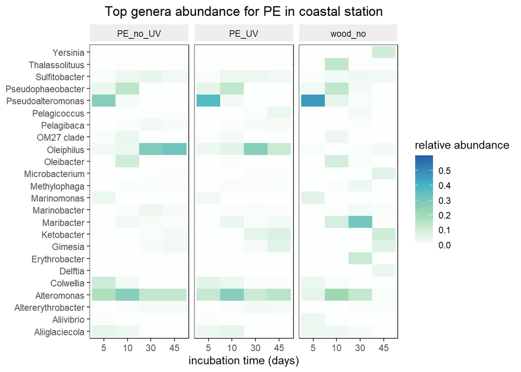

```r
pe_coast_top5
```

Now same logic for offshore station.

```r
os_uv_g5 <- os_uv %>% select(timepoint.days.,detail, Genus, Genus_rep_rel_abund, st_dev_Genus_abund) %>%
  mutate(across(c(timepoint.days.),factor))%>% distinct() %>%
  group_by(timepoint.days.) %>% slice_max(order_by = Genus_rep_rel_abund, n = 5)
os_nuv_g5 <- os_nuv %>% select(timepoint.days.,detail, Genus, Genus_rep_rel_abund, st_dev_Genus_abund) %>%
  mutate(across(c(timepoint.days.),factor))%>% distinct() %>%
  group_by(timepoint.days.) %>% slice_max(order_by = Genus_rep_rel_abund, n = 5)
os_n_g5 <- os_n %>% select(timepoint.days.,detail, Genus, Genus_rep_rel_abund, st_dev_Genus_abund) %>%
  mutate(across(c(timepoint.days.),factor))%>% distinct() %>%
  group_by(timepoint.days.) %>% slice_max(order_by = Genus_rep_rel_abund, n = 5)
```

```r
unique(c(os_nuv_g5$Genus,os_uv_g5$Genus, os_n_g5$Genus) )
```

```
##  [1] "Pseudarcobacter"           "Vibrio"
##  [3] "Pseudoalteromonas"         "Marinomonas"
##  [5] "Poseidonibacter"           "Alteromonas"
##  [7] "Neptunomonas"              "Colwellia"
##  [9] "Neptuniibacter"            "Abyssivirga"
## [11] "Ketobacter"                "Gimesia"
## [13] "Hyphomonas"                "Oleiphilus"
## [15] "Pseudophaeobacter"         "Fuerstia"
## [17] "Pseudomonas"               "SM1A02"
## [19] "Aliivibrio"                "Defluviitaleaceae UCG-011"
## [21] "Taeseokella"               "Alkalimarinus"
## [23] "Marinobacter"              "Sneathiella"
## [25] "Pelagicoccus"              "Thalassolituus"
## [27] "Algicola"                  "Sulfitobacter"
## [29] "Maribacter"                "Altererythrobacter"
## [31] "Clade Ia"                  "Synechococcus CC9902"
## [33] "NS5 marine group"          "Aurantivirga"
## [35] "Microbacterium"            "Lewinella"
## [37] "BIyi10"                    "P3OB-42"
```

```r
os_top5 <- os %>% select(timepoint.days.,detail,polymer_photo, Genus, Genus_rep_rel_abund, st_dev_Genus_abund) %>%
  mutate(across(c(timepoint.days.),factor)) %>%
  distinct()%>% filter(Genus %in% (unique(c(os_nuv_g5$Genus,os_uv_g5$Genus, os_n_g5$Genus))))
```

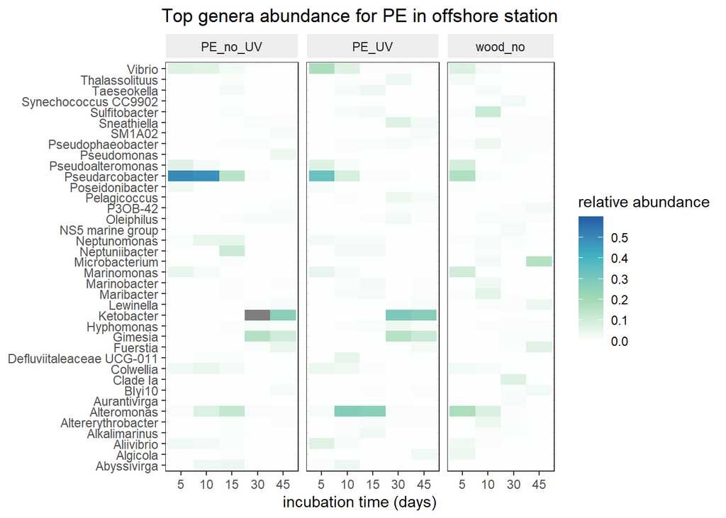

```r
plot(pe_os_top5)
```

### Polyethylene Tetraphtalate:

#### 1. Importing data:

Same as previous polymer.

```r
###############data import#########
pet <- read_csv("./new/PE462_PET.csv")
pet <- pet %>% filter(Genus %nin% c("unassigned", "Unassigned"))
############subset per station##########
coast <- pet %>% filter(station %in% c("C05"))
os <- pet %>% filter(station %in% c("C13"))
#####subset stations per treatment#####
coast_uv <- coast %>% filter(treatment %in% c("UV"))
coast_nuv <- coast %>% filter(treatment %in% c("no_UV"))
coast_n <- coast %>% filter(treatment %in% c("no"))
##same for 2nd station
os_uv <- os %>% filter(treatment %in% c("UV"))
os_nuv <- os %>% filter(treatment %in% c("no_UV"))
os_n <- os %>% filter(treatment %in% c("no"))
```

#### 2. Determining top genera:

here I determined the top 5 genera for each subset of the coastal station and each timepoint.

```r
coast_uv_g5 <- coast_uv %>% select(timepoint.days.,detail, Genus, Genus_rep_rel_abund, st_dev_Genus_abund) %>%
  mutate(across(c(timepoint.days.),factor))%>% distinct() %>%
  group_by(timepoint.days.) %>% slice_max(order_by = Genus_rep_rel_abund, n = 5)
coast_nuv_g5 <- coast_nuv %>% select(timepoint.days.,detail, Genus, Genus_rep_rel_abund, st_dev_Genus_abund) %>%
  mutate(across(c(timepoint.days.),factor))%>% distinct() %>%
  group_by(timepoint.days.) %>% slice_max(order_by = Genus_rep_rel_abund, n = 5)
coast_n_g5 <- coast_n %>% select(timepoint.days.,detail, Genus, Genus_rep_rel_abund, st_dev_Genus_abund) %>%
  mutate(across(c(timepoint.days.),factor))%>% distinct() %>%
  group_by(timepoint.days.) %>% slice_max(order_by = Genus_rep_rel_abund, n = 5)
```

These are the “total” top genera:

```r
unique(c(coast_nuv_g5$Genus,coast_uv_g5$Genus, coast_n_g5$Genus) )
```

```
##  [1] "Pseudoalteromonas" "Pseudophaeobacter" "Aliiglaciecola"
##  [4] "Colwellia"         "Marinomonas"       "Maribacter"
##  [7] "Alteromonas"       "Sulfitobacter"     "Arenibacter"
## [10] "Oleiphilus"        "Fuerstia"          "Gimesia"
## [13] "Cm1-21"            "Sneathiella"       "Tateyamaria"
## [16] "Saccharospirillum" "Erythrobacter"     "Aliivibrio"
## [19] "Thalassolituus"    "Oleibacter"        "Methylophaga"
## [22] "Ketobacter"        "Yersinia"          "Microbacterium"
## [25] "Delftia"
```

Now back to station subsets to extract the top genera for each

```r
coast_top5 <- coast %>% select(timepoint.days.,detail,polymer_photo, Genus, Genus_rep_rel_abund, st_dev_Genus_abund) %>%
  mutate(across(c(timepoint.days.),factor)) %>%
  distinct()%>% filter(Genus %in% (unique(c(coast_nuv_g5$Genus,coast_uv_g5$Genus, coast_n_g5$Genus))))
```

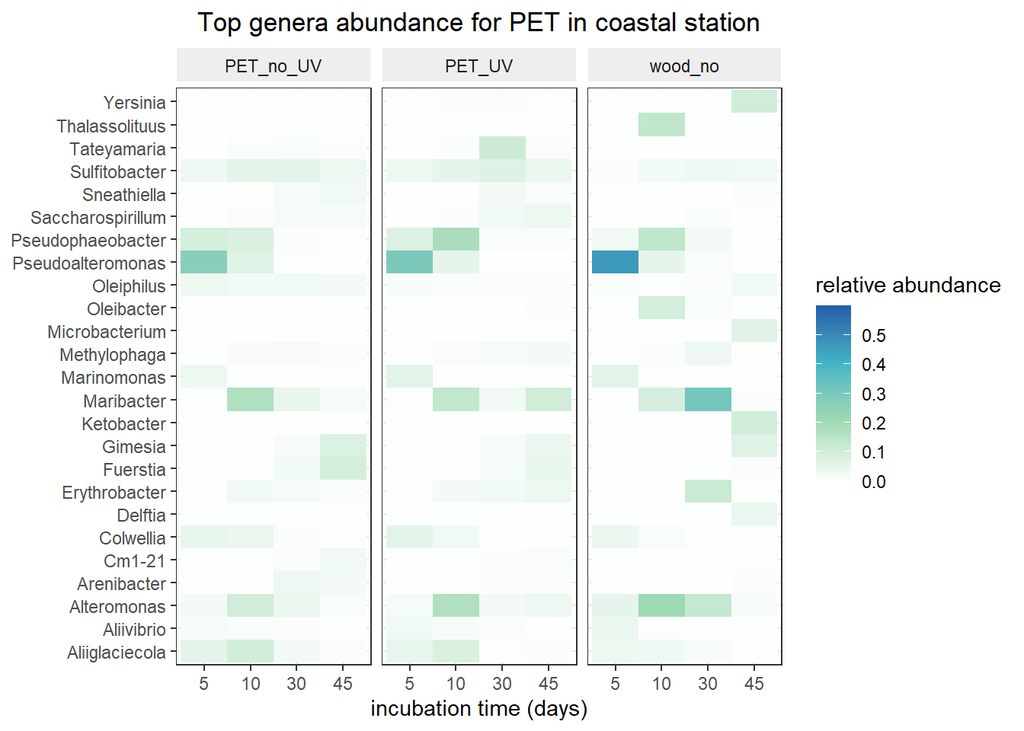

```r
plot(pet_coast_top5)
```

```r
os_uv_g5 <- os_uv %>% select(timepoint.days.,detail, Genus, Genus_rep_rel_abund, st_dev_Genus_abund) %>%
  mutate(across(c(timepoint.days.),factor))%>% distinct() %>%
  group_by(timepoint.days.) %>% slice_max(order_by = Genus_rep_rel_abund, n = 5)
os_nuv_g5 <- os_nuv %>% select(timepoint.days.,detail, Genus, Genus_rep_rel_abund, st_dev_Genus_abund) %>%
  mutate(across(c(timepoint.days.),factor))%>% distinct() %>%
  group_by(timepoint.days.) %>% slice_max(order_by = Genus_rep_rel_abund, n = 5)
os_n_g5 <- os_n %>% select(timepoint.days.,detail, Genus, Genus_rep_rel_abund, st_dev_Genus_abund) %>%
  mutate(across(c(timepoint.days.),factor))%>% distinct() %>%
  group_by(timepoint.days.) %>% slice_max(order_by = Genus_rep_rel_abund, n = 5)
```

```r
unique(c(os_nuv_g5$Genus,os_uv_g5$Genus, os_n_g5$Genus) )
```

```
##  [1] "Alteromonas"          "Vibrio"               "Pseudarcobacter"
##  [4] "Pseudoalteromonas"    "Aliivibrio"           "Maribacter"
##  [7] "Sulfitobacter"        "Thalassotalea"        "Neptunomonas"
## [10] "Lewinella"            "BIyi10"               "P3OB-42"
## [13] "Fuerstia"             "Pseudohongiella"      "Pseudophaeobacter"
## [16] "Neptuniibacter"       "Dasania"              "Flavobacterium"
## [19] "Altererythrobacter"   "Pelagicoccus"         "Magnetospira"
## [22] "Marinomonas"          "Clade Ia"             "Synechococcus CC9902"
## [25] "NS5 marine group"     "Aurantivirga"         "Pseudomonas"
## [28] "Microbacterium"
```

```r
os_top5 <- os %>% select(timepoint.days.,detail,polymer_photo, Genus, Genus_rep_rel_abund, st_dev_Genus_abund) %>%
  mutate(across(c(timepoint.days.),factor)) %>%
  distinct()%>% filter(Genus %in% (unique(c(os_nuv_g5$Genus,os_uv_g5$Genus, os_n_g5$Genus))))
```

[figure not shown]

```r
plot(pet_os_top5)
```

### Polystyrene:

#### 1. Importing data:

Same as previous polymer.

```r
###############data import#########
ps <- read_csv("./new/PE462_PS.csv")
ps <- ps %>% filter(Genus %nin% c("unassigned", "Unassigned"))
############subset per station##########
coast <- ps %>% filter(station %in% c("C05"))
os <- ps %>% filter(station %in% c("C13"))
#####subset stations per treatment#####
coast_uv <- coast %>% filter(treatment %in% c("UV"))
coast_nuv <- coast %>% filter(treatment %in% c("no_UV"))
coast_n <- coast %>% filter(treatment %in% c("no"))
##same for 2nd station
os_uv <- os %>% filter(treatment %in% c("UV"))
os_nuv <- os %>% filter(treatment %in% c("no_UV"))
os_n <- os %>% filter(treatment %in% c("no"))
```

#### 2. Determining top genera:

here I determined the top 5 genera for each subset of the coastal station and each timepoint.

```r
coast_uv_g5 <- coast_uv %>% select(timepoint.days.,detail, Genus, Genus_rep_rel_abund, st_dev_Genus_abund) %>%
  mutate(across(c(timepoint.days.),factor))%>% distinct() %>%
  group_by(timepoint.days.) %>% slice_max(order_by = Genus_rep_rel_abund, n = 5)
coast_nuv_g5 <- coast_nuv %>% select(timepoint.days.,detail, Genus, Genus_rep_rel_abund, st_dev_Genus_abund) %>%
  mutate(across(c(timepoint.days.),factor))%>% distinct() %>%
  group_by(timepoint.days.) %>% slice_max(order_by = Genus_rep_rel_abund, n = 5)
coast_n_g5 <- coast_n %>% select(timepoint.days.,detail, Genus, Genus_rep_rel_abund, st_dev_Genus_abund) %>%
  mutate(across(c(timepoint.days.),factor))%>% distinct() %>%
  group_by(timepoint.days.) %>% slice_max(order_by = Genus_rep_rel_abund, n = 5)
```

These are the “total” top genera:

```r
unique(c(coast_nuv_g5$Genus,coast_uv_g5$Genus, coast_n_g5$Genus) )
```

```
##  [1] "Pseudoalteromonas" "Alteromonas"       "Pseudophaeobacter"
##  [4] "Marinomonas"       "Colwellia"         "Maribacter"
##  [7] "Sulfitobacter"     "Rubinisphaera"     "Gimesia"
## [10] "Rhodopirellula"    "Marinobacter"      "Eionea"
## [13] "Aliivibrio"        "Thalassolituus"    "Oleibacter"
## [16] "Erythrobacter"     "Methylophaga"      "Ketobacter"
## [19] "Yersinia"          "Microbacterium"    "Delftia"
```

Now back to station subsets to extract the top genera for each

```r
coast_top5 <- coast %>% select(timepoint.days.,detail,polymer_photo, Genus, Genus_rep_rel_abund, st_dev_Genus_abund) %>%
  mutate(across(c(timepoint.days.),factor)) %>%
  distinct()%>% filter(Genus %in% (unique(c(coast_nuv_g5$Genus,coast_uv_g5$Genus, coast_n_g5$Genus))))
```

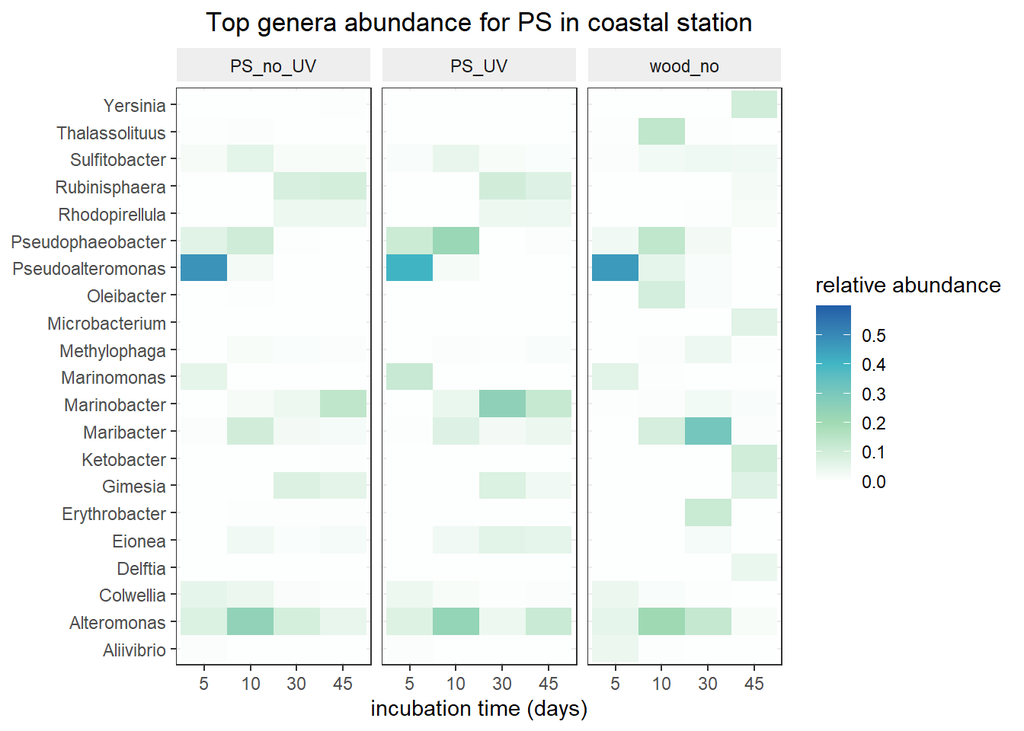

```r
plot(ps_coast_top5)
```

```r
os_uv_g5 <- os_uv %>% select(timepoint.days.,detail, Genus, Genus_rep_rel_abund, st_dev_Genus_abund) %>%
  mutate(across(c(timepoint.days.),factor))%>% distinct() %>%
  group_by(timepoint.days.) %>% slice_max(order_by = Genus_rep_rel_abund, n = 5)
os_nuv_g5 <- os_nuv %>% select(timepoint.days.,detail, Genus, Genus_rep_rel_abund, st_dev_Genus_abund) %>%
  mutate(across(c(timepoint.days.),factor))%>% distinct() %>%
  group_by(timepoint.days.) %>% slice_max(order_by = Genus_rep_rel_abund, n = 5)
os_n_g5 <- os_n %>% select(timepoint.days.,detail, Genus, Genus_rep_rel_abund, st_dev_Genus_abund) %>%
  mutate(across(c(timepoint.days.),factor))%>% distinct() %>%
  group_by(timepoint.days.) %>% slice_max(order_by = Genus_rep_rel_abund, n = 5)
```

```r
unique(c(os_nuv_g5$Genus,os_uv_g5$Genus, os_n_g5$Genus) )
```

```
##  [1] "Pseudarcobacter"                "Alteromonas"
##  [3] "Algicola"                       "Pseudoalteromonas"
##  [5] "Neptunomonas"                   "Sulfitobacter"
##  [7] "Taeseokella"                    "Acinetobacter"
##  [9] "Yersinia"                       "Delftia"
## [11] "Enhydrobacter"                  "Fuerstia"
## [13] "Gimesia"                        "Planctomicrobium"
## [15] "BIyi10"                         "Pseudomonas"
## [17] "Paracoccus"                     "Vibrio"
## [19] "Thalassolituus"                 "Maribacter"
## [21] "Pseudophaeobacter"              "Carnobacterium"
## [23] "Methylobacterium-Methylorubrum" "Marinobacter"
## [25] "Sneathiella"                    "SM1A02"
## [27] "Pseudohongiella"                "Marinomonas"
## [29] "Altererythrobacter"             "Clade Ia"
## [31] "Synechococcus CC9902"           "NS5 marine group"
## [33] "Aurantivirga"                   "Microbacterium"
## [35] "Lewinella"                      "P3OB-42"
```

```r
os_top5 <- os %>% select(timepoint.days.,detail,polymer_photo, Genus, Genus_rep_rel_abund, st_dev_Genus_abund) %>%
  mutate(across(c(timepoint.days.),factor)) %>%
  distinct()%>% filter(Genus %in% (unique(c(os_nuv_g5$Genus,os_uv_g5$Genus, os_n_g5$Genus))))
```

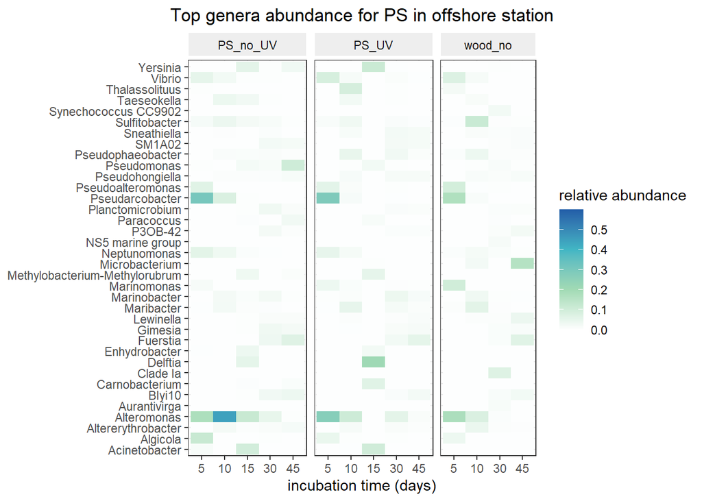

```r
plot(ps_os_top5)
```

### Nylon:

#### 1. Importing data:

Same as previous polymer.

```r
###############data import#########
Nylon <- read_csv("./new/PE462_Nylon.csv")
Nylon <- Nylon %>% filter(Genus %nin% c("unassigned", "Unassigned"))
############subset per station##########
coast <- Nylon %>% filter(station %in% c("C05"))
os <- Nylon %>% filter(station %in% c("C13"))
#####subset stations per treatment#####
coast_uv <- coast %>% filter(treatment %in% c("UV"))
coast_nuv <- coast %>% filter(treatment %in% c("no_UV"))
coast_n <- coast %>% filter(treatment %in% c("no"))
##same for 2nd station
os_uv <- os %>% filter(treatment %in% c("UV"))
os_nuv <- os %>% filter(treatment %in% c("no_UV"))
os_n <- os %>% filter(treatment %in% c("no"))
```

#### 2. Determining top genera:

here I determined the top 5 genera for each subset of the coastal station and each timepoint.

```r
coast_uv_g5 <- coast_uv %>% select(timepoint.days.,detail, Genus, Genus_rep_rel_abund, st_dev_Genus_abund) %>%
  mutate(across(c(timepoint.days.),factor))%>% distinct() %>%
  group_by(timepoint.days.) %>% slice_max(order_by = Genus_rep_rel_abund, n = 5)
coast_nuv_g5 <- coast_nuv %>% select(timepoint.days.,detail, Genus, Genus_rep_rel_abund, st_dev_Genus_abund) %>%
  mutate(across(c(timepoint.days.),factor))%>% distinct() %>%
  group_by(timepoint.days.) %>% slice_max(order_by = Genus_rep_rel_abund, n = 5)
coast_n_g5 <- coast_n %>% select(timepoint.days.,detail, Genus, Genus_rep_rel_abund, st_dev_Genus_abund) %>%
  mutate(across(c(timepoint.days.),factor))%>% distinct() %>%
  group_by(timepoint.days.) %>% slice_max(order_by = Genus_rep_rel_abund, n = 5)
```

These are the “total” top genera:

```r
unique(c(coast_nuv_g5$Genus,coast_uv_g5$Genus, coast_n_g5$Genus) )
```

```
##  [1] "Pseudoalteromonas"  "Pseudophaeobacter"  "Colwellia"
##  [4] "Marinomonas"        "Psychrobium"        "Alteromonas"
##  [7] "Maribacter"         "Sulfitobacter"      "Marinobacter"
## [10] "Pseudarcobacter"    "Microbacterium"     "Gimesia"
## [13] "Croceicoccus"       "Altererythrobacter" "Ketobacter"
## [16] "Cyclobacterium"     "Vibrio"             "Neptunomonas"
## [19] "Abyssivirga"        "Amphritea"          "Saccharophagus"
## [22] "Kordiimonas"        "Aliivibrio"         "Thalassolituus"
## [25] "Oleibacter"         "Erythrobacter"      "Methylophaga"
## [28] "Yersinia"           "Delftia"
```

Now back to station subsets to extract the top genera for each

```r
coast_top5 <- coast %>% select(timepoint.days.,detail,polymer_photo, Genus, Genus_rep_rel_abund, st_dev_Genus_abund) %>%
  mutate(across(c(timepoint.days.),factor)) %>%
  distinct()%>% filter(Genus %in% (unique(c(coast_nuv_g5$Genus,coast_uv_g5$Genus, coast_n_g5$Genus))))
```

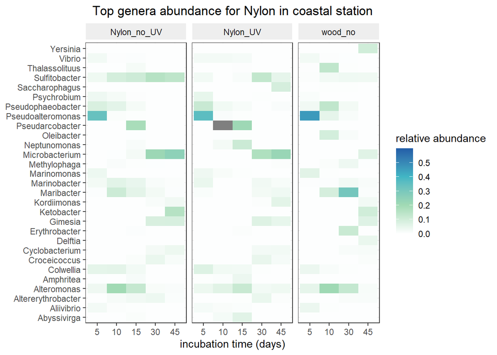

```r
plot(Nylon_coast_top5)
```

```r
os_uv_g5 <- os_uv %>% select(timepoint.days.,detail, Genus, Genus_rep_rel_abund, st_dev_Genus_abund) %>%
  mutate(across(c(timepoint.days.),factor))%>% distinct() %>%
  group_by(timepoint.days.) %>% slice_max(order_by = Genus_rep_rel_abund, n = 5)
os_nuv_g5 <- os_nuv %>% select(timepoint.days.,detail, Genus, Genus_rep_rel_abund, st_dev_Genus_abund) %>%
  mutate(across(c(timepoint.days.),factor))%>% distinct() %>%
  group_by(timepoint.days.) %>% slice_max(order_by = Genus_rep_rel_abund, n = 5)
os_n_g5 <- os_n %>% select(timepoint.days.,detail, Genus, Genus_rep_rel_abund, st_dev_Genus_abund) %>%
  mutate(across(c(timepoint.days.),factor))%>% distinct() %>%
  group_by(timepoint.days.) %>% slice_max(order_by = Genus_rep_rel_abund, n = 5)
```

```r
unique(c(os_nuv_g5$Genus,os_uv_g5$Genus, os_n_g5$Genus) )
```

```
##  [1] "Pseudarcobacter"      "Neptunomonas"         "Vibrio"
##  [4] "Alteromonas"          "Thalassotalea"        "Dasania"
##  [7] "Sulfitobacter"        "Colwellia"            "Microbacterium"
## [10] "Croceicoccus"         "Lewinella"            "P3OB-42"
## [13] "Fuerstia"             "Pseudohongiella"      "Marinomonas"
## [16] "Marivivens"           "Maribacter"           "Altererythrobacter"
## [19] "Pseudophaeobacter"    "Lentisphaera"         "Pseudoalteromonas"
## [22] "Clade Ia"             "Synechococcus CC9902" "NS5 marine group"
## [25] "Aurantivirga"         "Pseudomonas"          "BIyi10"
```

```r
os_top5 <- os %>% select(timepoint.days.,detail,polymer_photo, Genus, Genus_rep_rel_abund, st_dev_Genus_abund) %>%
  mutate( polymer_photo = replace(polymer_photo, polymer_photo == "Nylon_wood_no", "ctrl_wood")) %>% mutate(across(c(timepoint.days.),factor)) %>%
  distinct()%>% filter(Genus %in% (unique(c(os_nuv_g5$Genus,os_uv_g5$Genus, os_n_g5$Genus))))
```

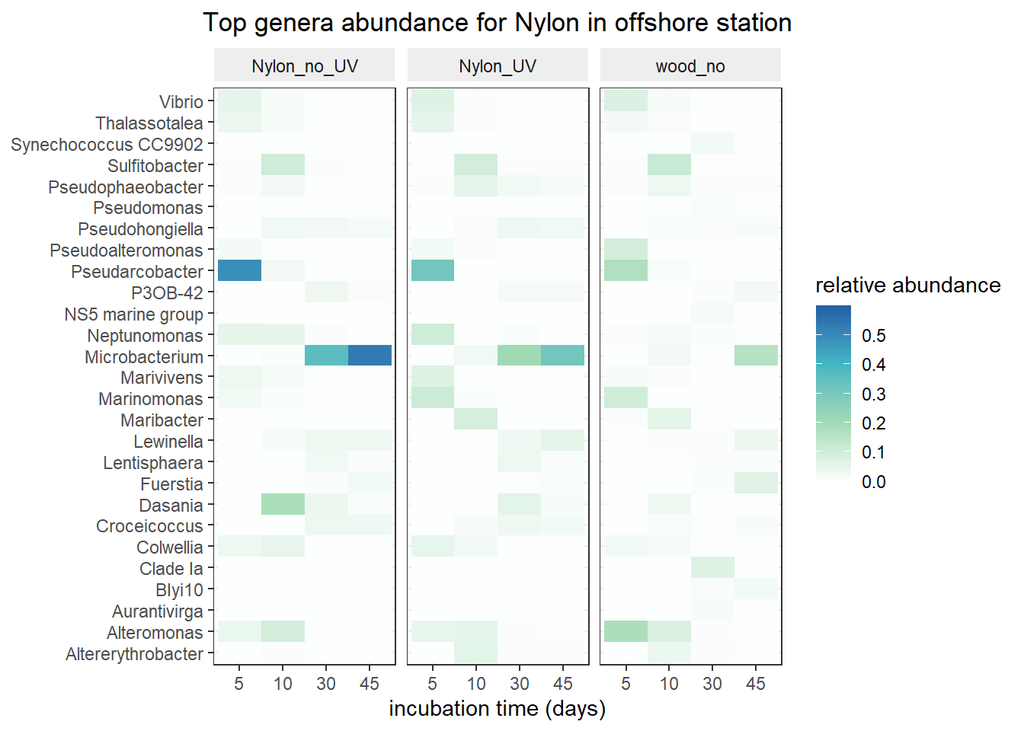

```r
plot(Nylon_os_top5)
```

### Beta Diversity:

I performed an nmds on the Genus dataset.

```r
gen <- read_csv("./new/genus_PE462.csv")
gen_count <- gen %>% filter(detail %nin% c("mock_DNA","Glass_fiber_no_C05_0", "Neg_PCR", "Glass_fiber_no_C13_0" )) %>%
  select(detail, Genus, Genus_rep_rel_abund) %>% mutate(across(c(Genus),factor)) %>%
  pivot_wider(names_from = detail, values_from = Genus_rep_rel_abund, values_fill = 0) %>% column_to_rownames(var = "Genus") %>% as.matrix()
gen_metadata <- gen %>% select( "detail","station","timepoint.days.","treatment", "polymer","pol_photo_station","polymer_station",
                                "polymer_photo","material") %>% filter(detail %nin% c("mock_DNA","Glass_fiber_no_C05_0", "Neg_PCR",
                                "Glass_fiber_no_C13_0" )) %>% distinct() %>% column_to_rownames(var = "detail")
pseq <- merge_phyloseq(otu_table(gen_count, taxa_are_rows = T), sample_data(gen_metadata))
```

```r
ord <- ordinate(pseq, method = "NMDS", k = 2, "bray",trymax = 150)
```

```
## *** Solution reached
```

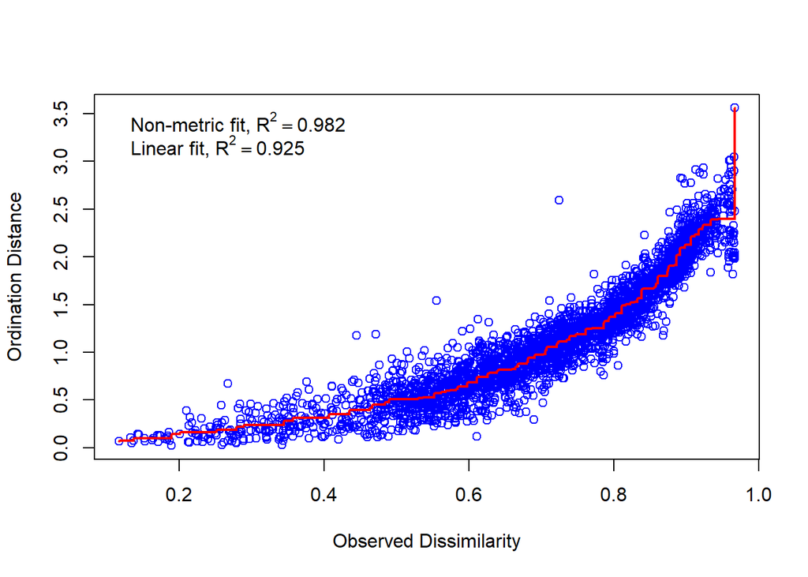

```r
stressplot(ord)
```

```r
head(ord$points)
```

```
##                         MDS1       MDS2
## PE_UV_C05_10      -0.2962133  0.2352858
## PE_no_UV_C13_5    -1.1881923 -0.6176542
## PS_no_UV_C05_5    -1.1295596  0.5620585
## PS_UV_C05_5       -1.2284115  0.5219204
## Nylon_no_UV_C13_5 -1.1249713 -0.6095164
## Nylon_UV_C05_10   -1.2578350 -0.6798531
```

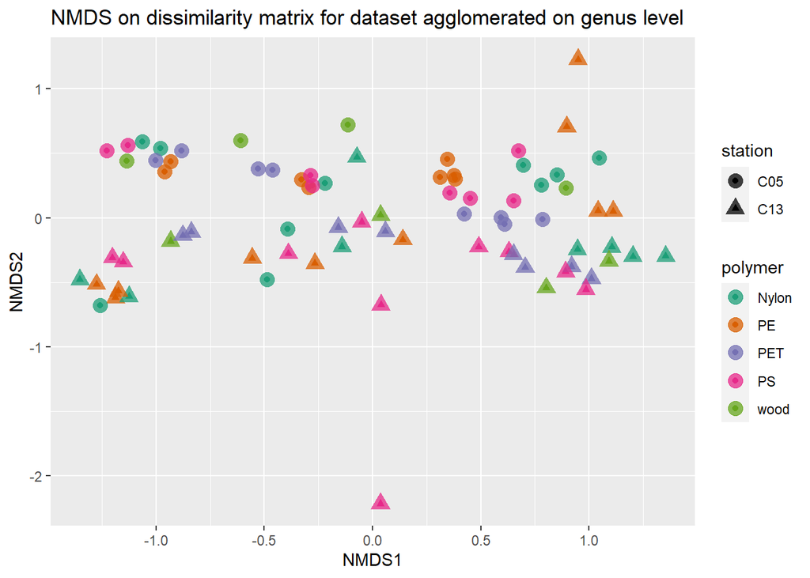

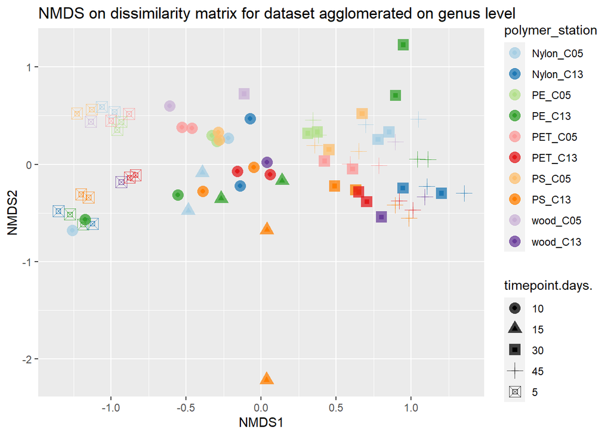

```r
#knitr::knit_exit()
```